# Mathematical Proof

Autumn 2025

## What is a proof

> A mathematical proof is a **deductive argument** for a mathematical statement, showing that the stated assumptions **logically guarantee** the conclusion.
- **Deductive reasoning**
  - Conclusions are drawn from two or more statements (premises).
  - Premises must be true for the conclusion to be sound.
- The goal is to convince the reader.
- Theorem: literally *“that which is looked at”*,

  from theōrein “to look at”, “behold”.

## Behold, Pythagoras’ Theorem!

For a right-angled triangle, the square of the long side is equal to the sum of the squares of the two shorter sides.

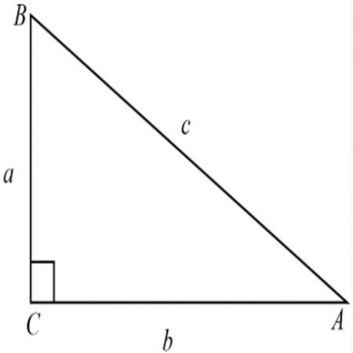

- The Greeks introduced the idea of proof.
- Previously, civilisations like the Babylonians and Egyptians used specific numerical examples.

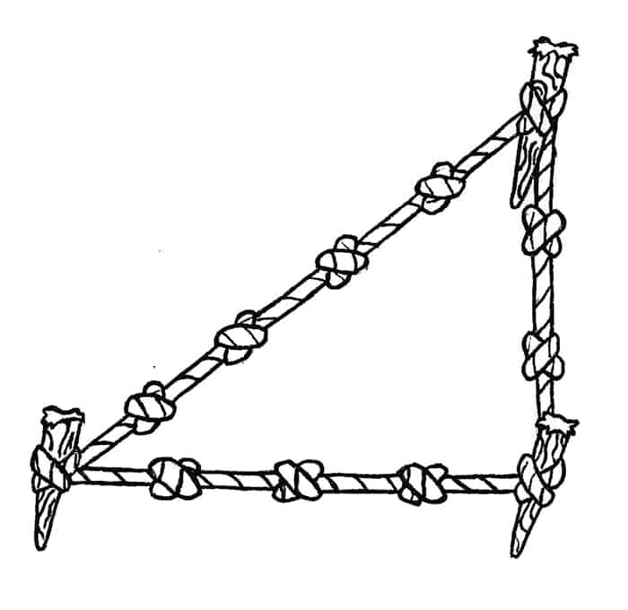

## A re-arrangement proof

We will show that \(c^2\) is the same as the sum of the areas of \(a^2\) and \(b^2\).

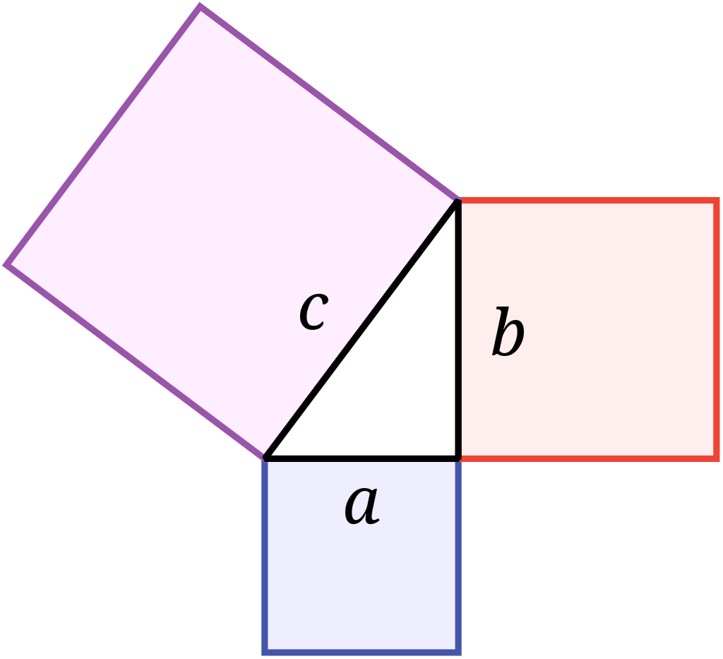

## A re-arrangement proof

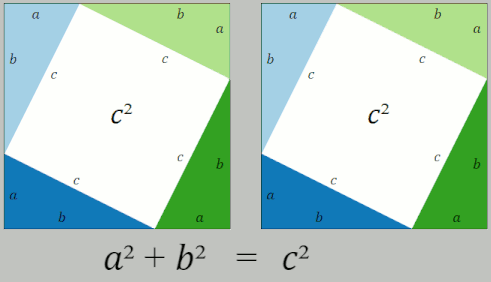

## The mutilated chessboard

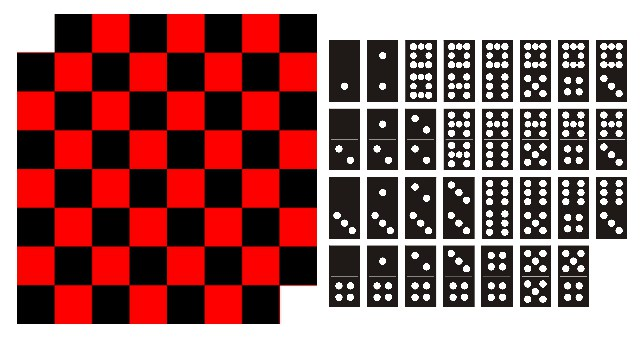

Can you cover all the squares, and only the squares with the dominos?

- We need to cover \((8 \cdot 8) - 2 = 62\) squares with dominos.
- We have \(32\) black squares and \(30\) white squares (\(2\) white removed).
- Let us *assume* that it is possible.
- Each domino covers exactly two squares.
- Neighbouring squares have different colours.
- So each domino must cover *one white* and *one black* square.
- Every time a domino is placed, the number of available white and black squares each decreases by 1.
- Since there is an *unequal number* of black and white squares…
- We will reach a point when some squares are uncovered but no more dominos can be placed.
- In other words, there will be *two black squares* left, but this is impossible to cover with one domino, since neighbouring squares have different colours.

## Mathematical Rigor

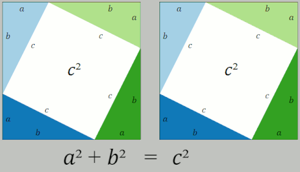

Animated proof of pythagoras theorem

*Are you convinced?*

## Mathematicians demand undisputable proof

- *Astronomer*: all Scotch sheep are black!
- *Physicist*: no, only *some* Scotch sheep are black.
- *Mathematician* (eye roll) in Scotland, there exists at least one field containing at least one sheep, at least one side of which is black.

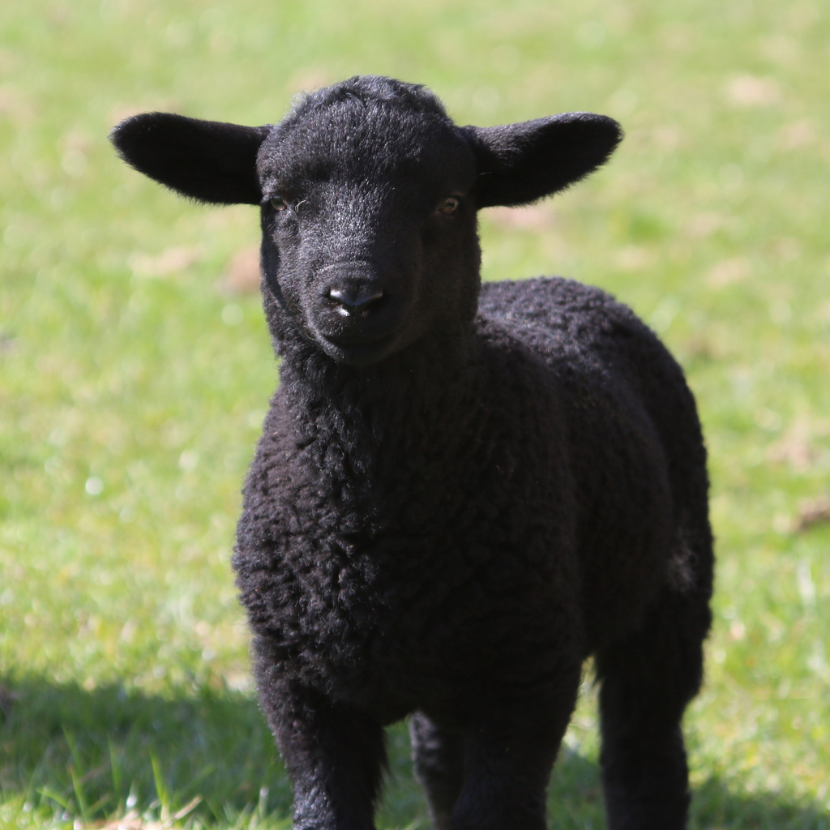

– Ian Stuart, Concepts of Modern Mathematics

## A rigorous argument

- Euclid’s elements presented definitions, axioms, and proofs.
- Started with simple, self-evident statements such as “a straight line passes through two distinct points” (axioms).
- Built up theories on areas of rectangles, parallelograms, and triangles.
- Statements depended only on the axioms and previously proved statements.

## Algebra

- Developed in China, India and the Islamic world, but not used by the Greeks.
- Used symbols such as \(x\) and \(y\) to represent unknown quantities.
- Made famous by al-Khwarizmi.
- Algebra still depended on geometry for its proofs.

## Completing the square

A method of solving a quadratic equation \(ax^2 + bx + c = 0\).

[video not shown]

## Example of completing the square

Solve \(x^2 + 10x = 39\).

- \(x^2 + 10x = x \cdot x + x \cdot 5 + 5 \cdot x\)

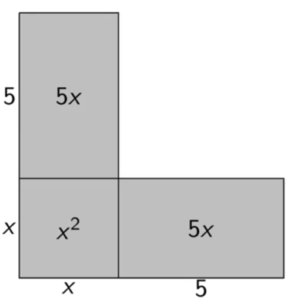

## Example of completing the square

Solve \(x^2 + 10x = 39\).

- Shaded area is equal to \(39\), remaining area in the square is \(25 = 5\cdot 5\)

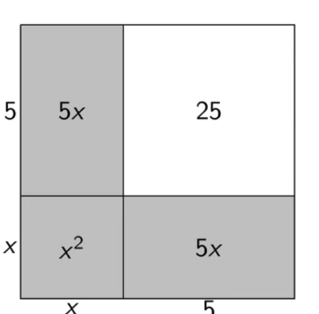

## Example of completing the square

Solve \(x^2 + 10x = 39\).

- Square has area \(39 + 25 = 64 = 8^2\)

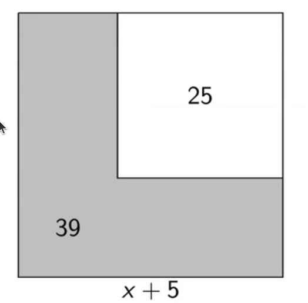

## Arithmetic with symbols

Later, mathematicians performed arithmetic with symbols:

- \(x^2 + 10x = 39\); rewrite as
- \(x^2 + 5x + 5x = 39\) (shaded L-shape);
- observe that inner square has sides of length \(5\); add \(5^2\) to both sides
- \(x^2 + 5x + 5x + 25 = 39 + 25 = 64 = 8^2\)
- square has sides of length \(x+5\); rewrite
- \((x+5)^2 = 8^2\), so \(x + 5 = 8\).

… achieving the same result as the geometric argument we just saw.

## Geometrie de Descartes

- Represents geometric objects, e.g., the circle with radius \(1\),
- as algebraic objects. i.e., an equation \(x^2 = y^2 = 1\).

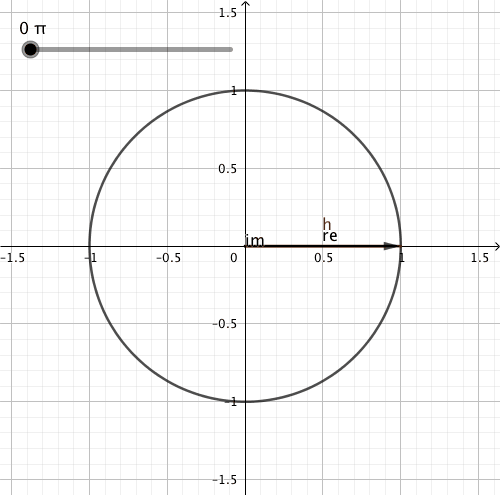

- Newton called this technique “Universal Arithmetic”.
- Leibnitz had the idea of reducing **logic** to computation.

## Propositional logic

- George Boole described part of logic by using symbols

  \(\land, \lor, \neg\) and variables such as \(A,B,X,Y\).
- This was a type of **algebra**, where variables could take values \(0\) or \(1\).

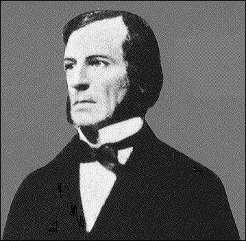

George Boole

## First-order logic

- Boolean logic is powerful,
- But not powerful enough to express all statements, e.g.,
  - \(x^2 \ge 0\) no matter the value of \(x\), or
  - \(21\) is divisible by \(3\),

    i.e., there is an integer \(m\) such that \(21 = 3 \cdot m\).

## First-order logic

- Adds *quantifiers* to logical statements
  - \(\forall\): “for all”, “for every”,
  - \(\exists\): “for some” [at least one], “there exists”.
- Quantifiers indicade *how many* elements of a given set satisfy a proposition.

## Example

- Input set: \(P\) the set of all people in G32 right now.
- Proposition “*person \(p\) drinks water*”
- Now we can quantify our proposition:
  - For **every** person \(p\) in \(P\), \(p\) drinks water.
  - Proposition drinks water is true for every element of the set \(P\).

## Example

- Input set: \(P\) the set of all people in G32 right now.
- Proposition “*person \(p\) likes coffee*”
- Now we can quantify our proposition:
  - There **exists** a person \(p\) in \(P\), such that \(p\) likes coffee.
  - Proposition likes coffee is true for at least one element in the set \(P\).

## Multiple quantifiers

- Input set: \(P\) set of people.
- Proposition: *\(c\) has a biological mother \(m\)*.
- For **every** person \(c\), **there exists** a person \(m\) such that \(c\) has the biological mother \(m\)
  - Meanning: every person has a biological mother.
  - Strictly speaking, at least one…

## Multiple quantifiers

- Input set: \(P\) set of people.
- Proposition: *\(c\) has a biological mother \(m\)*.
- There **exists** a person \(m\) such that **for every** person \(c\), \(c\) has the biological mother \(m\)
  - Meaning?
  - There is at least one peerson who is the biological mother of all people.

Order of quantifiers is important!

## Hilbert’s Program

- Around the end of the 19th Century, David Hilbert proposed a project to return mathematics to basic principles.
- Proofs could only depend on basic axioms.
- Hilbert’s goals:
  1. Show that every mathematical queestion could be answered,
  2. and mathematics was free from inconsistencies.

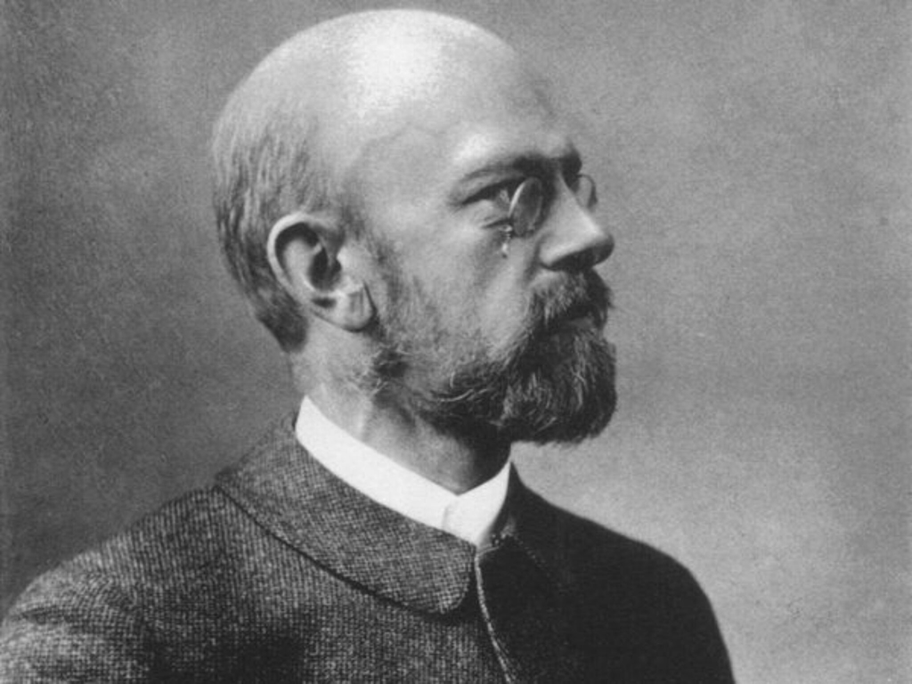

On 8 August 1900, Hilbert gives a talk at the International Congress of Mathematicians in Paris, posing his 23 fundamental problems.

## Back to Axioms

- An axiom is a well-defined, simple, self-evident statement.
- Frege axiamotised predicate logic so we could identify logically valid formulas
- These axioms were sufficient to deduce **all** logically valid formulas!

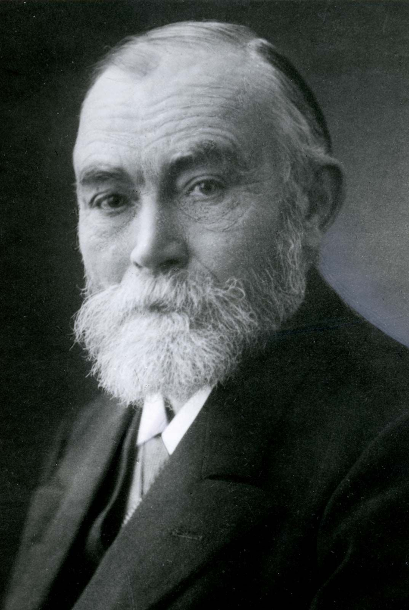

Derived hundreds of theorems from just the basic axioms.

## What is \(3\)

- Frege endeavoured to properly define what numbers meant.
- Used sets: the set \(3\) was defined by

  **the set containing all sets of three things**.
- Something exhibited *threeness* if it was in the set \(3\).
- Frege used this principle to publish “Fundamental laws of arithmetic”.

## Bertrand Russell

- Meanwhile, Bertrand Russell found an inconsistency involving sets.
- At first thought it was an easy fix, spent the latter half of 1901 working on it and realised it was a fundamental problem.
- Wrote to Frege, whosee manuscript was already being printed.
- Frege addad a post-script:

  “… a scientist can experience nothing worse than having the foundation give way just as work is finished …”

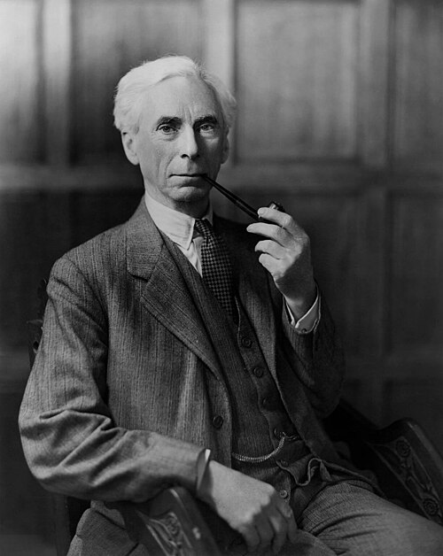

## Russell’s Paradox

- Sets are collections of objects.
- Sometimes a set is not a member of itself, eg..,

  *the class of teaspoons*.
- But other times, a set is a member of itself, e.g.,

  *the set of things which are not teaspoons*

## The Russell Set

\[ R := \{x \vert x \not in x\} \]

- The set of all sets which *do not contain themselves*.
- Members include nice sets like the natural numbers, teaspoons, Discworld characters, dogs, cats…
- But… should \(R\) be a member of \(R\)?

## The Tale of the meticulous Librarian

- A librarian finds a stack of catalogs.
- Each catalog lists books in the library: fiction, non-fiction, poetry, textbooks, etc.
- Some of the catalogues list themselves, others do not.
- The Librarian decides to catalog the catalogs.

[figure not shown]

“Ook!”

## The Tale of the meticulous Librarian

- He makes a catalog of catalogs which *do not list themselves*.
- Should it contain catalog of catalogs which do not list themselves?
  - Yes: but then the catalog of catalogs which do not list themselve would list itself.
  - No: but then the catalog of catalogs that do not list themselves would not list a catalog which does not list itself.

[figure not shown]

“Ook!”

- Both cases end in a contradiction.

> "…but you might say none of this shakes my belief that two and two makes four. You are quite right, except in marginal cases and it is only in marginal cavses you are doubtful that a certain animal is a dog or a certain length is less than a metre. Two must be two of something, and the proposition two and two is four is useless unless it can be applied. Two dogs and two dogs are certainly four dogs, but there are certain cases when you are doubtful that two of them are dogs. Well, in any case, there are four animals, you might say, but there are microorganisms of which it is doubtful as to whether they are animals. Alright, two living things, then. But there are organisms of which it is debated as to whether tehy are living or not. You will be driven to say: two entities and two entities are four entities.

> When you have told me what you men by entity, we will resume the argument.

– Bertrand Russell

## One more axiom

- “A set cannot be a member of itself”.
- In 1910, Albert North Whitehead published the first volume of Principia Mathematica.
- for the next two decades, the foundations of mathematics seemed firm.

## Kurt Godel

- Published “On formally undecidable problems in Principia Mathamatica…” in 1931.
- Presented two *incompleteness theorems*:

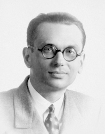

## Godel’s incompleteness theorems

1. If axiomatic set theory is consistent, then there exist conjectures that can neither be proved nor disproved,

Whichever axioms you use, completeness can never be achieved.

1. There is no constructive procedure which will prove that an axiomatic theory is consistent,

Mathematicians cannot be certain that their axioms will never lead to contradiction.

## The liar’s paradox

- **I ama liar**.
- “God exists because mathematics is consistent; the Devil exists because we cannot prove it”

  –André Weil
- Hilbert’s program was ruined.

## Undecidable problems

- In 1963, Paul Cohen proved that the Continuum Hypothesis was undecidable.
- One of Hilbert’s 23 fundamental problems was proved unsolvable!

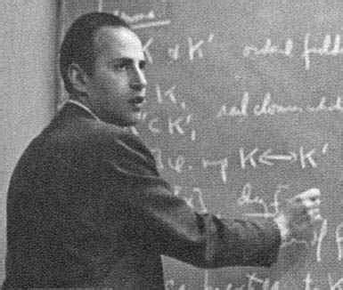

## Undecidable Problems

- Hilbert’s 10th problem:
  - Decide whether a polynomial equation with integer coefficients and a finite number of unknowns has integer solutions
  - proved undecidable in 1970 by Yuri Matiyasevich, Julia Robinson, Martin Davis, and Hilary Putnam

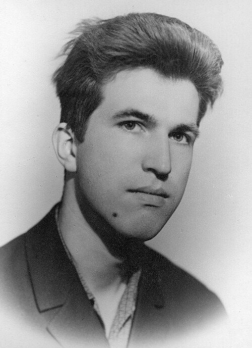

## The Halting Problem

Can an algorithm be created to check whether any program will *halt* (run to completion without errors) or not (run indefinitely or crash)?

## Lean

## What is Lean

- Lean is a full programming language and a **proof assistant**.
- A proof assistant allows you to do deductive logic and ensures all your deductions are valid and sound.
- Lean checks your proofs, in very simple terms, by performing some very strict type-checking.
- A proof in lean is called a *“goal”*
- You solve it by applying *“tactics”* to make logical deductions until you’re left with \(\mathrm{True} \equiv \mathrm{True}\).

## Back (again) to Axioms

- We’ll be using a proof assistant called *Lean* to prove facts about the natural numbers.
- We begin with just the definition of the natural numbers:
  - The first natural number is \(0\)
  - Given any natural number \(n\), the next one is given by \(\rm{succ}(n)\).

Representing numbers like this is known as the [Peano axioms](https://en.wikipedia.org/wiki/Peano_axioms).

- …and two tools (Lean calls them *tactics*):
  - `rw` lets you *“rewrite”* a statement by replacing one thing with another,
    - if we have an assumption `h : x = 32`,
    - and a goal `x + 1 = 32 + 1`,
    - we *rewrite* `h` which replaces `x` in our goal with `32` to give

      `32 + 1 = 32 + 1`
  - `rfl` says that \(a = a\) is true, for any exprossion \(a\).
    - I.e., both sides of the `=` sign are identical.
    - Given `32 + 1 = 32 + 1`
    - We can use `rfl` to assert that both sides of the equals sigs match…

  … closing our goal and completing our proof.

## Addition of natural numbers

- We saw that there are two cases in our definition of the natural numbers:
  - \(0\) (the first natural number),
  - and `succ` (which gives us the next natural number).
- Let’s define \(a + b\) for two natural numbers \(a\) and \(b\).
  - If \(b = 0\) then \(a + b = a + 0 = a\),
  - Otherwise, \(a + \rm{succ}(b) = \rm{succ}(a + b)\).

And that’s all we need to prove all the things about addition!

## Lab Task: the Natural Number Game

- Go to https://adam.math.hhu.de/#/g/leanprover-community/nng4
- Start with Tutorial World, which introduces goals, tactics `rw` and `rfl` and introduces you to the natural numbers.